# New York City Motor Vehicle and People Collision Analysis

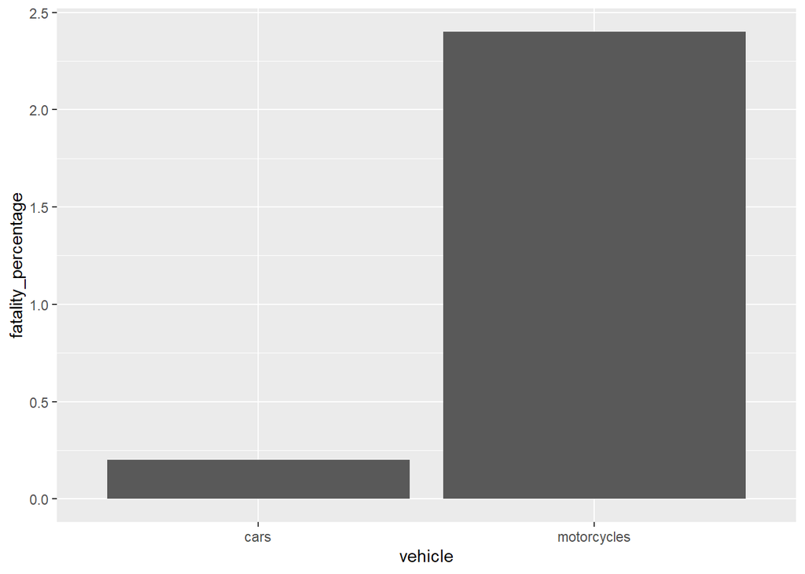

```r
ggplot(fatality_df, aes(vehicle, fatality_percentage)) +
  geom_col()
```

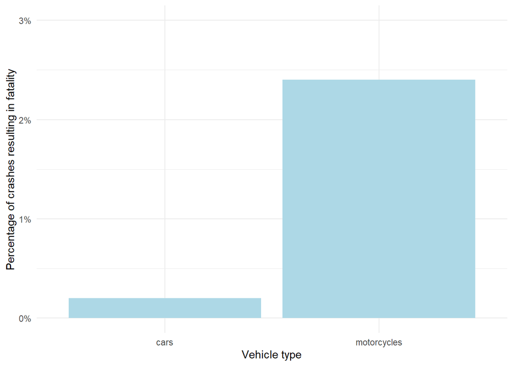

```r
ggplot(fatality_df, aes(vehicle, fatality_percentage)) +
  geom_col(fill = "lightblue") +  # Set bar color to blue
  scale_y_continuous(limits = c(0, 3), labels = scales::percent_format(scale = 1)) +  # Set y-axis limits and format as percentage
  labs(x = "Vehicle type", y = "Percentage of crashes resulting in fatality") +  # Set axis labels
  theme_minimal()  # Optional: Use a minimal theme for better aesthetics
```

### **Method:**

Three main variables are involved: `Vehicle Type Code 1` (VTC1), `Vehicle Type Code 2`(VTC2), and `Number of Persons Killed`. The type codes describe what kind of vehicles were involved in the crash. Starting with deadly motorcycle crashes, the conjoined dataset was filtered to omit all observations when zero deaths occured. In other words, looked only at deadly crashes. From there the dataset was filtered to keep only observations where “Motorcycle” appeared as either `VTC1` or `VTC2`. The same was applied for car crashes by instead omitting “Motorcycle” with the ! logical condition.

However, this was not a comprehensive look at motor and car crashes because there exists over 1,000 VTCs in the dataset - many of which were motorcycle equivalents for our purposes. For example, electric bikes and motorized scooters can be classified as Motorcycles for our purposes. To account for motorcycle equivalents, I pulled the column VTC1 and identified names containing the character “motor” and “bike.” Some irrelevant names showed up like “motor home” which is not a motorcycle equivalent. I stored these names in a new variable called Motrocycle_equivalents and removed the irrelevant names.

### **Results:**

My results convey that motorcycles are **more dangerous than cars**. People should be more careful around motorcycles because they are **more likely to cause fatality**.

## **What is the most likely cause of collisions?**

The variables that were most relevant for this question were the variable names:

- `CONTRIBUTING.FACTOR.VEHICLE.1`
- `CONTRIBUTING.FACTOR.VEHICLE.2`
- `CONTRIBUTING.FACTOR.VEHICLE.3`
- `CONTRIBUTING.FACTOR.VEHICLE.4`
- `CONTRIBUTING.FACTOR.VEHICLE.5`
- `CONTRIBUTING_FACTOR_1`
- `CONTRIBUTING_FACTOR_2`

Only the values in this column were needed, as in this case, any column that did not pertain to the contributing factors in collisions was unnecessary. To filter out the rest of the data, I used the filter function to filter out columns that were not the contributing factor one, as well as values that were empty in that column. This entire process along with the conversion of the wide format structure to a long format structure was stored into a new variable called `crashesPersonLong`

To find the frequency, I made a new variable called counts, that takes in `crashesPersonLong` and counts each occurrence of each value in that column, and those were titled `Frequency`. Then, I filtered `counts` to only display the values that had an occurrence of over 9000, as the values with a frequency less than this are more negligible when considering the scale of the data.

Then, the `counts` variable was updated to exclude the value that the data had as “unspecified’ as this value has no use for the analysis of the data.

To visualize the data and see the results, it was necessary to plot it. The `ggplot()` command was used to take in the `counts` data. The aesthetics that were applied consisted of x equalling the contributing factor, and the y being the frequency. They were ordered using `reorder()` to be displayed from highest to lowest frequency. Columns were used to visualize the data and they were colored pink. I then flipped the data using `coord_flip()` to display the x values on a vertical axis and y on a horizontal axis for better readability, then titled the plot accordingly. Overall the plot showed the frequency of each contributing variable.

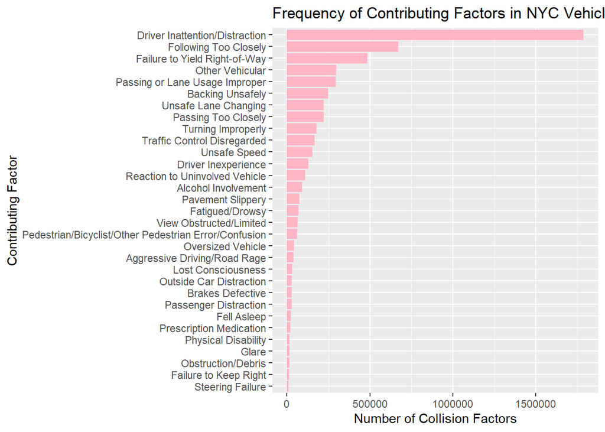

```r
filteredData <- crashesPerson %>%
  filter(!is.na(`CONTRIBUTING FACTOR VEHICLE 1`) |
         !is.na(`CONTRIBUTING FACTOR VEHICLE 2`) |
         !is.na(`CONTRIBUTING FACTOR VEHICLE 3`) |
         !is.na(`CONTRIBUTING FACTOR VEHICLE 4`) |
         !is.na(`CONTRIBUTING FACTOR VEHICLE 5`) |
         !is.na(CONTRIBUTING_FACTOR_1) |
         !is.na(CONTRIBUTING_FACTOR_2))

filteredData <- filteredData %>%
  select(`CONTRIBUTING FACTOR VEHICLE 1`,
         `CONTRIBUTING FACTOR VEHICLE 2`,
         `CONTRIBUTING FACTOR VEHICLE 3`,
         `CONTRIBUTING FACTOR VEHICLE 4`,
         `CONTRIBUTING FACTOR VEHICLE 5`,
         CONTRIBUTING_FACTOR_1,
         CONTRIBUTING_FACTOR_2)

crashesPersonLong <- filteredData %>%
  pivot_longer(cols = everything(),
               names_to = "Factor_Type",
               values_to = "Contributing_Factor_in_All_Vehicles")

crashesPersonLong <- crashesPersonLong %>%
  filter(!is.na(Contributing_Factor_in_All_Vehicles))

counts <- crashesPersonLong %>%
  count(Contributing_Factor_in_All_Vehicles, name = "Frequency") %>%
  filter(Frequency > 9000)

counts <- counts[counts$Contributing_Factor_in_All_Vehicles != "Unspecified",]

ggplot(counts, aes(x = reorder(Contributing_Factor_in_All_Vehicles, Frequency),
                   y = Frequency)) +
  geom_col(fill = "pink1")+
  coord_flip()+
  labs(title = "Frequency of Contributing Factors in NYC Vehicle Collisions",
       x = "Contributing Factor",
       y = "Number of Collision Factors")
```

### **Trade-Offs:**

One trade-off that accompanied my decisions was the choice to exclude the values that had less than 9000 occurrences. This was because if they were included in the plot, their frequency was so low, it appeared as if they were 0. This showed me that they were negligible and were not a big factor in collisions as they were very specific and not something that is a common cause of a collision that everyday people would have to take into account. Another trade off was focusing solely on the direct contributing factors rather than other potential contextual features of the dataset.

### **Results:**

With the plot visualization, the **most likely cause of collisions is driver inattention/distraction**. Followed by this is “Following Too Closely”, “Failure to Yield Right of Way” and “Other Vehicular” tied with “Improper Passing or Lane Usage”.

### **Findings:**

My results have shown that distracted driving is the most likely cause of collisions. This shows that one should limit all distractions when behind the wheel, be sure to focus on the road ahead, and be aware of what one is doing in regards to other cars and pedestrians. Limitations may include a lack of impact to pedestrians and what they can do to stay safe, as distracted driving falls solely on the driver. Another limitation can include the fact that there were numerous cases with an unspecified cause of collision. This could lead to a potentially incomplete understanding of collision causes. Additionally, the choice to focus on the most common contributing factors may not capture and address nuanced relationships between them. Further steps that can be taken to extend the story can include understanding different interactions between the contributing factors and other variables. This would potentially need other datasets that are detailed. One can also compare the cause of collisions in New York City to other regions and analyze whether certain contributing factors are more prevalent in specific areas.

Distracted driving is the leading cause of vehicle collisions, highlighting the critical **need for drivers to minimize distractions** and **stay focused** on the road. However, the analysis may overlook the significance of less common factors and lacks consideration of broader contextual elements. Future work should explore interactions between various contributing factors, incorporate additional contextual data, and possibly compare findings across different regions to gain a more comprehensive understanding of collision causes.

## **Do crash rates vary by month?**

To first find how crash rates vary by month, the month chould be extracted from the `CRASH_DATE` variable. This was done by selecting the numbers in the first and second index of the variable, which is the month in mm/dd/yyyy format. Only the months were needed to answer this question. Labels were then created that assigned each month in numerical form to the corresponding month’s full categorical classification. Then, a new column called `month` was created that replaced the numerical form with the categorical form.

After this, a monthly summary data frame was created where a variable titled `totalCrashes` counts the number of crashes that occurs in each month. The months were then put into chronological order by using the `factor()` function and `month.name` function.

To visualize the data, a bar chart was created where the x-axis represented the different months and the y-axis represented the number of crashes.

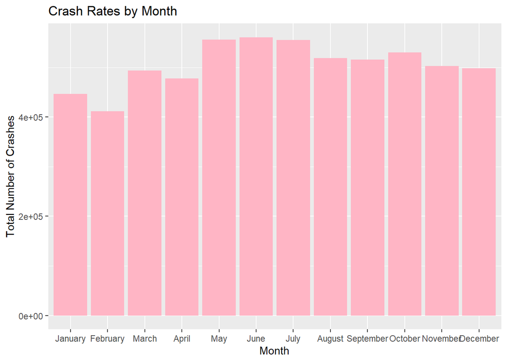

```r
crashesPerson$month <- substr(crashesPerson$CRASH_DATE, 1, 2)

monthLabel<- c("01" = "January", "02" = "February", "03" = "March", "04" = "April",
                  "05" = "May", "06" = "June", "07" = "July", "08" = "August",
                  "09" = "September", "10" = "October", "11" = "November", "12" = "December")

crashesPerson$month <- monthLabel[crashesPerson$month]

monthlySummary <- crashesPerson %>%
  group_by(month) %>%
  summarize(
    totalCrashes = n())

monthlySummary$month <- factor(monthlySummary$month, levels = month.name)

ggplot(monthlySummary, aes(x = month, y = totalCrashes)) +
  geom_col(fill = "pink1") +
  labs(title = "Crash Rates by Month",
       x = "Month",
       y = "Total Number of Crashes")
```

### **Trade-Offs:**

A trade-off with this research question is that I grouped the data by month and created discrete, monthly groups that may not completely capture other factors such as trends that a more advanced time series could potentially show. The var chart also does not show variation within a month, so a more nuanced view that shows changes over time or peak crashes within a month isn’t possible.

### **Results:**

The result of the data is that **June is the month with the highest collisions**. It is then followed by May, then July. These are summer/late spring months and the increase in crash counts could be due to the increased foot and vehicle traffic in warmer weather. Outdoor activities could also lead to roads being closed off, which can result in a more complicated driving experience. There could also be riskier driving behaviors due to a lack of caution about the weather when it is sunny. Additionally, higher temperatures can impact vehicle equipment, such as tire pressure, and cause blowouts. [(Buckingham and Vega Law Firm)](https://www.medmal-law.com/blog/2022/june/how-do-high-temperatures-affect-tires-/#:~:text=For%20every%2010%C2%B0F,essential%20component%20of%20driving%20safely.)

### **Findings:**

Knowing that June, May, and July are the months with the highest collision rates, one can infer that the increase in travel and outdoor activities during warmer months could contribute to this heightened rate. Increasing traffic control presence during summer months could help manage the surge in traffic and reduce accidents. Limitations to consider could be that the data does not account for unreported collisions or almost collisions, which could provide additional context. To further answer this question, one could assess and differentiate between different types of collisions, such as those involving only vehicles versus those involving pedestrians or cyclists, which can provide more insight.

Knowing *when* motor vehicle collisions are most likely to happen is the crucial first step in preventing them. By using this knowledge, pedestrians, cyclists, and drivers in New York City can take proactive measures to protect themselves.

## **What Neighborhood are these Collisions Most Likely to Occur?**

### **Method:**

The variables that were used to project this data were total collisions and the names of the five boroughs in New York City. Before graphing the data, one problem that needed to be fixed was processing the NA values. To fix this, the NA and blank values had to be filtered out. The sample that was used for this research question was all the observations that could be processed by the computer and R. The samples were taken from the `CRASH` and `PERSON` datasets that were later merged.

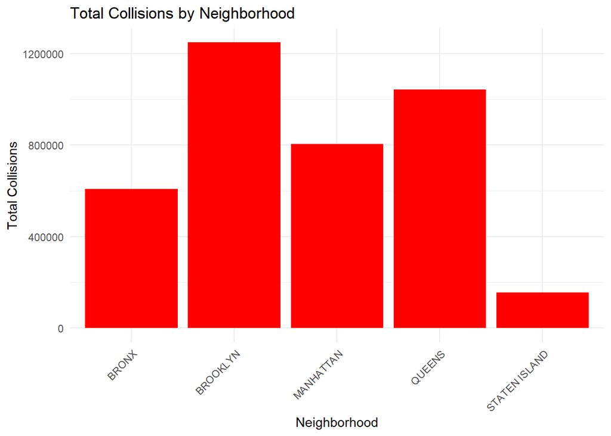

```r
BOROUGH_collisions <- crashesPerson %>%
  filter(!is.na(BOROUGH) & BOROUGH != "") %>%
  group_by(BOROUGH) %>%
  summarise(total_collisions = n())

ggplot(BOROUGH_collisions, aes(x = BOROUGH, y = total_collisions)) +
  geom_bar(stat = "identity", fill = "red") +
  theme_minimal() +
  labs(title = "Total Collisions by Neighborhood",
       x = "Neighborhood",
       y = "Total Collisions") +
  theme(axis.text.x = element_text(angle = 45, hjust = 1))
```

### **Trade-Offs:**

One of the biggest trade-offs with filtering out the NA values is that some observations in the dataset were unrecorded. Before filtering out the NA values, I noticed that when they were graphed, there were a significant number of values that belonged to this category. Whether they are high enough in number to affect the data is doubtful, but these NA values prevent the dataset from being 100% accurate.

### **Results:**

Based on the results of the bar graph, the **borough with the largest collisions is Brooklyn**. The borough with the least number of collisions is Staten Island, with significantly less compared to the other four boroughs. Another thing to note is that the volume of collisions in collisions is around the same amount of collisions of Manhattan and the Bronx combined.

### **Findings:**

In order to figure out the reason why collisions occur the most frequently in Brooklyn and a low number in Staten Island, I decided to read into the population of each borough to see if this was correlated to the number of collisions. **Brooklyn is the borough with the highest population** and Staten Island is the borough with the least number of people, which could indicate that the number of people in a given area is related to the number of collisions. This could be measured in the future. One limitation is that because there were some NA values that had to be filtered out, the graph doesn’t depict all the crash data. In the future, the coordinates of these NA values could be used to determine which borough these collisions occurred in.

All in all, Brooklyn is the borough with the highest number of collisions and the largest population. On the other hand, Staten Island has the least number of collisions and the smallest population.

# **Stakes: Why Does This Matter?**

Our results matter because our topic involves public safety, policy-making, and urban planning. We now understand the fatal causes and injuries, neighborhood impact, and which locations are more prone for accidents (eg. tourist locations).

This also can tie into neighborhood disparities and if certain areas are more affected by collisions.

Knowing the time of day crashes are more likely to occur or the time of year can influence traffic regulation or have implemented safety measures.

This also give us an idea of the economic impact and how many resources go to damaged property and injuries.